# final project

### c. Define the sensitivity and specificity of your classifier. How well does it recognize your own handwriting (make sure your handwriting is not in the training set)?

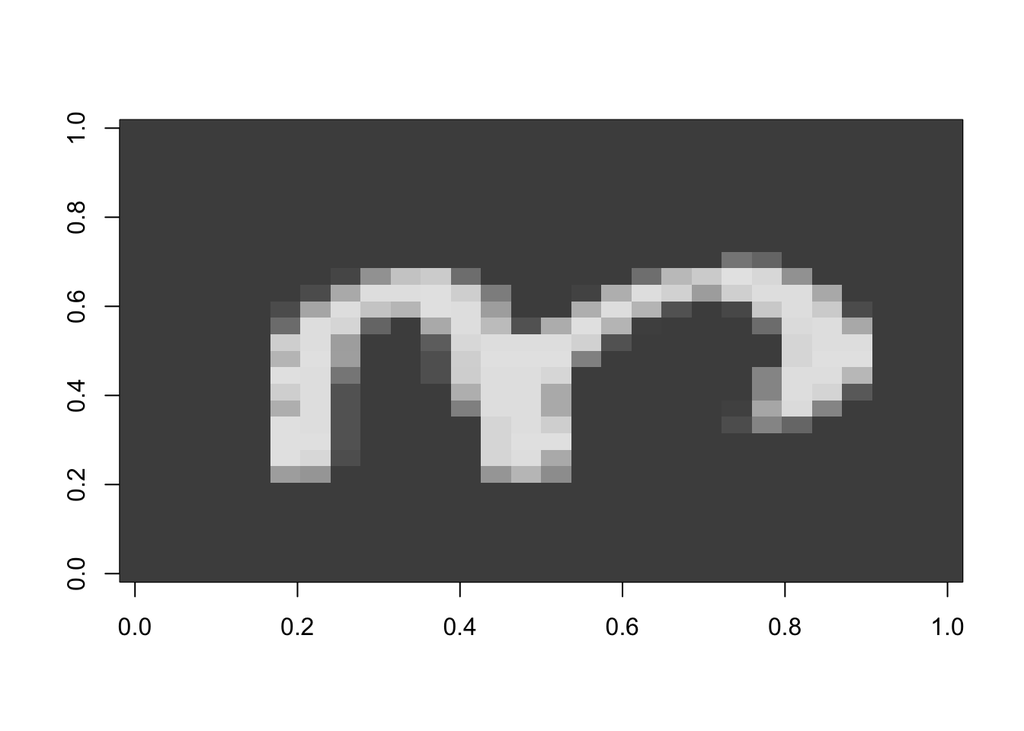

```r
set.seed(42)

own <- read.csv('test.csv')
own <- own[sample(nrow(own), 3), ]

plot_number(own, 1)
```

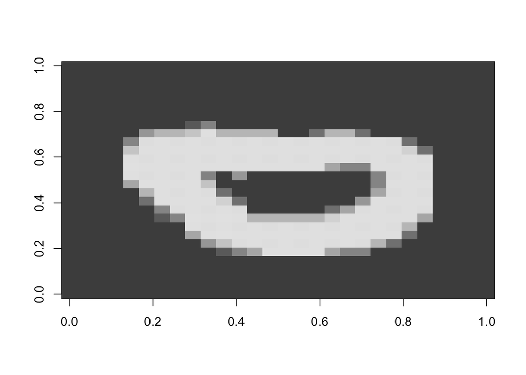

```r
plot_number(own, 2)
```

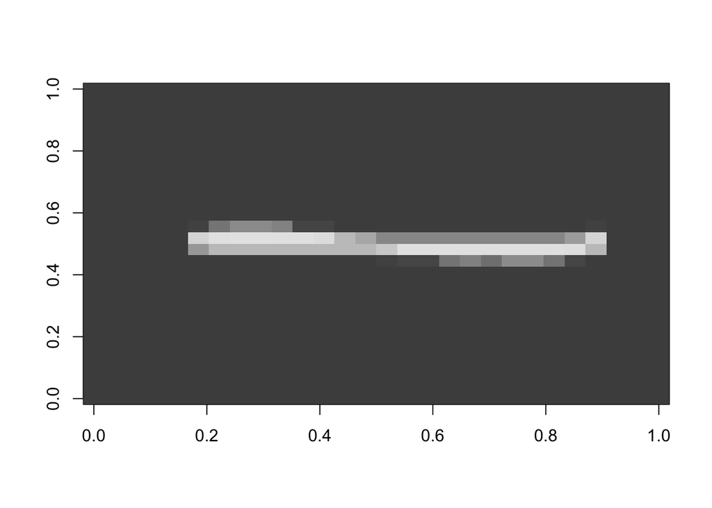

```r
plot_number(own, 3)
```

```r
own.pca <- predict(digits.pca, own)  # PCA transformed data
prediction <- predict(rf, newdata = own.pca[,1:n], type = "class")
print('Prediction:')
```

```
## [1] "Prediction:"
```

```r
prediction
```

```
## 27185 18753 21657
##     3     0     1
## Levels: 0 1 2 3 4 5 6 7 8 9
```

## • For dataset 2

### 1) Build hierarchical trees based on the columns

```r
col <- read.csv('Mnemiopsis_col_data.csv', header = TRUE)  # Read in data
library(data.tree)
col$pathString <- paste(col$type, col$condition, col$Sample, sep = "/")
tree <- as.Node(col)
tree
```

```
##           levelName
## 1  Mleidyi
## 2   ¦--aboral
## 3   ¦   ¦--aboral-1
## 4   ¦   ¦--aboral-2
## 5   ¦   ¦--aboral-3
## 6   ¦   °--aboral-4
## 7   °--oral
## 8       ¦--oral-1
## 9       ¦--oral-2
## 10      ¦--oral-3
## 11      °--oral-4
```

### 2) and for the rows (exclude rows that are “low” expression) Draw a heat map of the expression data

```r
# Read in Data and exclude low expression where tot is zero.
de <- read.csv('Mnemiopsis_count_data_fixed.csv',header=TRUE) # read the csv gene expression file
x <- de[, c(2:9)]
de$tot <- rowSums(x, na.rm=FALSE) #rowsums function to sum the expression data in each row.

summary(de$tot)
```

```
##    Min. 1st Qu.  Median    Mean 3rd Qu.    Max.
##       0     115    1054    4104    3362  977931
```

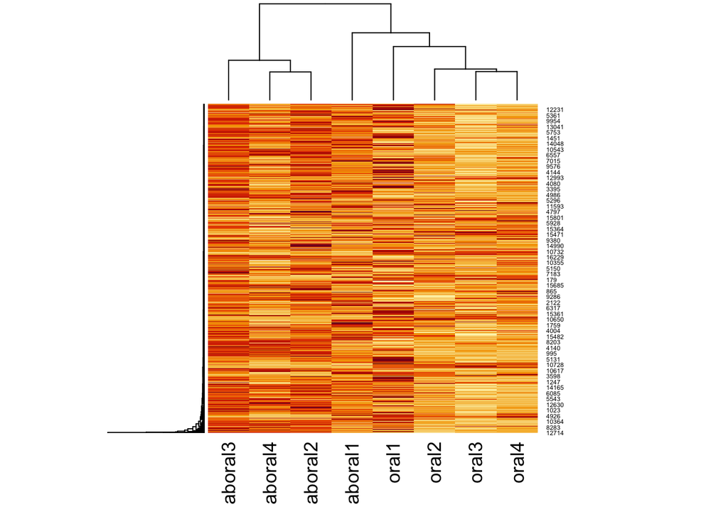

```r
threshold = 10  #less than 10 is low expression

de = de[de$tot > threshold, ] # filtered away low expression rows

data <- as.matrix(de[, 2:9])
heatmap(data)
```

### 3) Use DESeq2 to analyze this data

```r
library("DESeq2")
```

```r
library(ashr)
library(ggplot2)
# Import data from featureCounts
countdata <- read.table("Mnemiopsis_count_data_fixed.csv", header=TRUE, row.names=1,sep=",")
coldata <- read.table("Mnemiopsis_col_data.csv", header=TRUE, row.names=1,sep=",")
countdata <- as.matrix(countdata)
dds <- DESeqDataSetFromMatrix(countData=countdata, colData=coldata, design=~condition)
# Run the DESeq pipeline
dds <- DESeq(dds)
#eliminate background from genes with low counts
keep <- rowSums(counts(dds)) >= 10
dds <- dds[keep,]

#create a data frame for log fold change
res.shrunk <- lfcShrink(dds,type='ashr',contrast = c("condition","aboral","oral"))
```

```
## using 'ashr' for LFC shrinkage. If used in published research, please cite:
##     Stephens, M. (2016) False discovery rates: a new deal. Biostatistics, 18:2.
##     https://doi.org/10.1093/biostatistics/kxw041
```

```r
#reorder the expression result based on log fold change and p value for down regulated gene
res.shrunkOrdered <- res.shrunk[order(res.shrunk$pvalue),]
res.shrunkOrdered
```

```
## log2 fold change (MMSE): condition aboral vs oral
## Wald test p-value: condition aboral vs oral
## DataFrame with 14316 rows and 5 columns
##            baseMean log2FoldChange     lfcSE       pvalue         padj
##           <numeric>      <numeric> <numeric>    <numeric>    <numeric>
## ML087114a 15168.994      -12.92864  0.545820 7.55161e-131 1.07845e-126
## ML463533a   295.674       -5.46016  0.287760  5.74365e-81  3.91825e-77
## ML20265a    861.643       -7.28309  0.385393  8.23104e-81  3.91825e-77
## ML085213a  1265.181       -5.37231  0.284070  1.98648e-80  7.09224e-77
## ML01433a   9743.342       -5.69212  0.311210  1.80847e-75  5.16534e-72
## ...             ...            ...       ...          ...          ...
## ML29496a   54.88278      0.0190313  0.270386           NA           NA
## ML42511a    3.32691      0.3794496  1.257308           NA           NA
## ML42512a    7.09741      0.5494447  1.519851           NA           NA
## ML42513a    4.54678      0.4972968  1.419240           NA           NA
## ML451323a  84.15076      0.0785894  0.501168           NA           NA
```

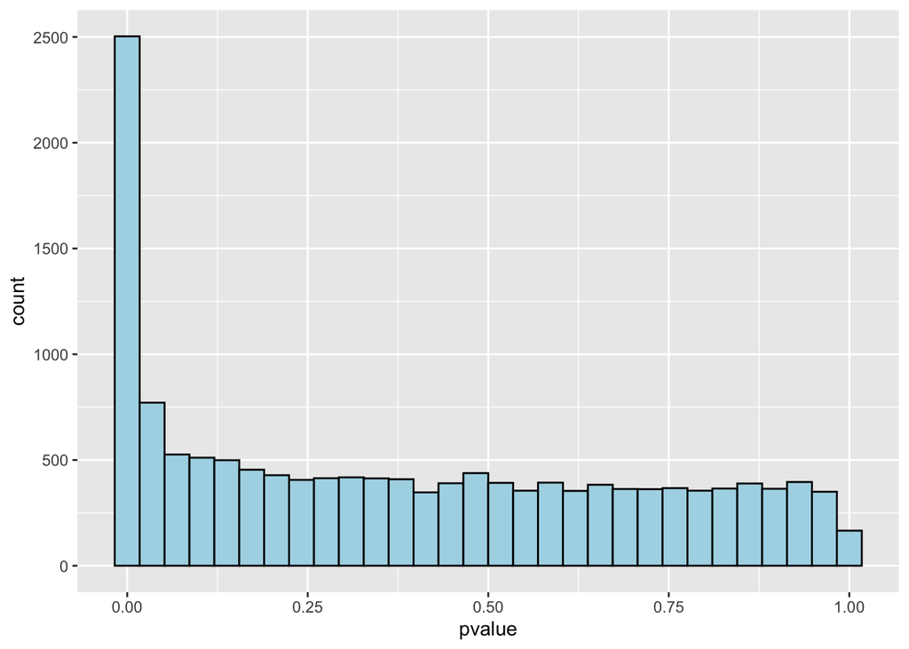

```r
##plot of p-values to historgram
ggplot(as.data.frame(res.shrunkOrdered),aes(pvalue)) + geom_histogram(fill="light blue",color='black')
```

```r
#plot dispersion
dds <- estimateDispersions(dds,fitType = c("parametric"))
```

```
## found already estimated dispersions, replacing these
```

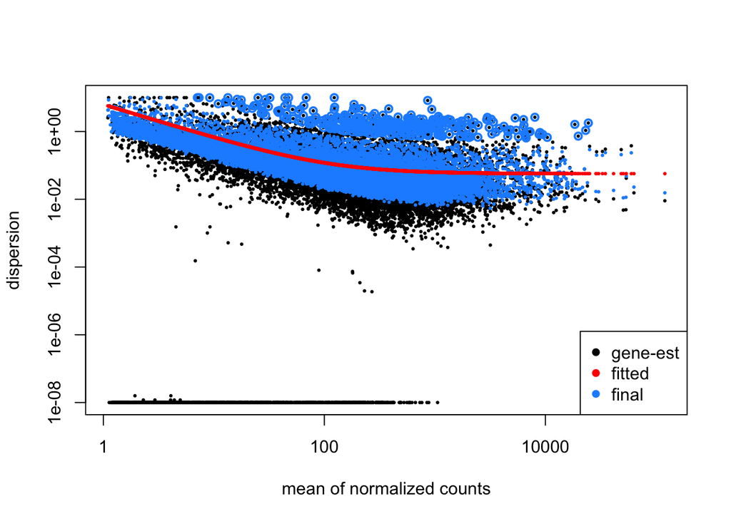

```r
plotDispEsts(dds)
```

```r
dds <- DESeq(dds)
```

```
## found already estimated dispersions, replacing these
```

```r
rawcounts.matrix <- counts(dds,normalized=F)
normalizedcounts.matrix <- counts(dds,normalized=T)
class(rawcounts.matrix)
```

```
## [1] "matrix" "array"
```

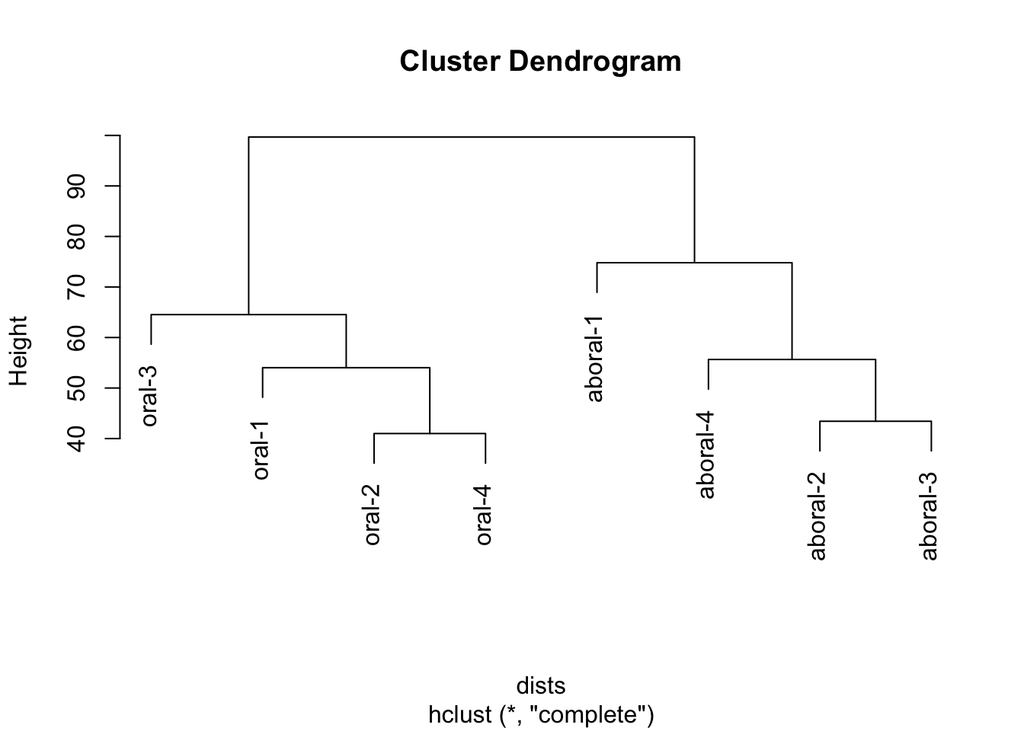

```r
#plot hierarchical trees base on gene expression
rld <- rlog(dds)
dists <- dist(t(assay(rld)))
plot(hclust(dists))
```

```r
res <- results(dds, contrast = c("condition","aboral","oral") )
class(res)
```

```
## [1] "DESeqResults"
## attr(,"package")
## [1] "DESeq2"
```

```r
summary(res)
```

```
##
## out of 14316 with nonzero total read count
## adjusted p-value < 0.1
## LFC > 0 (up)       : 1153, 8.1%
## LFC < 0 (down)     : 1360, 9.5%
## outliers [1]       : 35, 0.24%
## low counts [2]     : 0, 0%
## (mean count < 1)
## [1] see 'cooksCutoff' argument of ?results
## [2] see 'independentFiltering' argument of ?results
```

```r
res.shrunk <- lfcShrink(dds,type='ashr',contrast = c("condition","aboral","oral"))
```

```
## using 'ashr' for LFC shrinkage. If used in published research, please cite:
##     Stephens, M. (2016) False discovery rates: a new deal. Biostatistics, 18:2.
##     https://doi.org/10.1093/biostatistics/kxw041
```

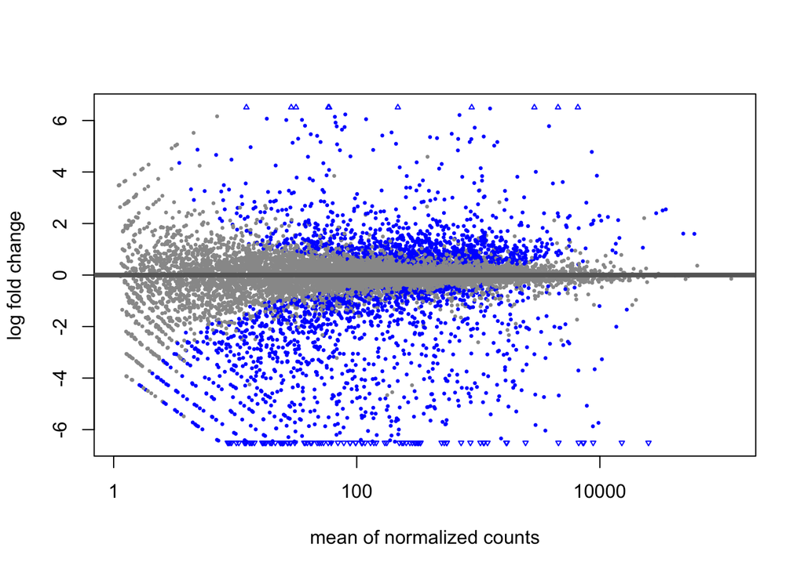

```r
res.shrunkOrdered <- res.shrunk[order(res.shrunk$pvalue),]

## MA plot to visualize differential expressed data.
plotMA(res)
```

```r
# Get differential expression results, order by adjusted p-value for up regulated gene
resSig <- subset(res.shrunkOrdered, log2FoldChange > 1 & padj < 0.05, )
resSig
```

```
## log2 fold change (MMSE): condition aboral vs oral
## Wald test p-value: condition aboral vs oral
## DataFrame with 432 rows and 5 columns
##            baseMean log2FoldChange     lfcSE      pvalue        padj
##           <numeric>      <numeric> <numeric>   <numeric>   <numeric>
## ML327424a  2892.591        8.48972  0.482911 9.40339e-71 1.34290e-67
## ML01051a    683.030        5.24370  0.299193 2.12123e-69 2.52444e-66
## ML00194a    350.125        3.65352  0.239206 5.27579e-53 3.42471e-50
## ML276914a   882.524        6.58346  0.514832 2.04179e-38 6.47975e-36
## ML030234a   876.621        5.18805  0.443682 3.28953e-32 7.57706e-30
## ...             ...            ...       ...         ...         ...
## ML02043a    4.57129        1.43780   1.38750  0.00552343   0.0390109
## ML034667a  11.06926        1.15642   1.07000  0.00553186   0.0390390
## ML040012a   7.48057        1.07781   1.02306  0.00622016   0.0429962
## ML087214a   5.60794        1.51755   1.54643  0.00624990   0.0431449
## ML00382a    4.33000        1.49097   1.57218  0.00688749   0.0468890
```

```r
#write in a tsv file
write.table(as.data.frame(resSig),
          file="diff_exp_results.tsv",sep = "\t")
```

### a. Which are the most significantly changing genes in this dataset?

```
          baseMean log2FoldChange     lfcSE       pvalue         padj
          <numeric>      <numeric> <numeric>    <numeric>    <numeric>
ML087114a 15168.994      -12.92864  0.545820 7.55161e-131 1.07845e-126
ML463533a   295.674       -5.46016  0.287760  5.74365e-81  3.91825e-77
ML20265a    861.643       -7.28309  0.385393  8.23104e-81  3.91825e-77
ML085213a  1265.181       -5.37231  0.284070  1.98648e-80  7.09224e-77
ML01433a   9743.342       -5.69212  0.311210  1.80847e-75  5.16534e-72

ML327424a  2892.591        8.48972  0.482911 9.40339e-71 1.34290e-67
ML01051a    683.030        5.24370  0.299193 2.12123e-69 2.52444e-66
ML00194a    350.125        3.65352  0.239206 5.27579e-53 3.42471e-50
ML276914a   882.524        6.58346  0.514832 2.04179e-38 6.47975e-36
ML030234a   876.621        5.18805  0.443682 3.28953e-32 7.57706e-30
```

### b. Which genes are most consistently highly expressed in these datasets that are the “house-keeping” genes?

```r
#sort the data based on base mean which log fold change are less than 0.5 in ascending order,
res.shrunkOrdered1 <- res.shrunk[order(res.shrunk$baseMean),]
resSig1 <- subset(res.shrunkOrdered1, log2FoldChange <0.5)
resSig1
```

```
## log2 fold change (MMSE): condition aboral vs oral
## Wald test p-value: condition aboral vs oral
## DataFrame with 13384 rows and 5 columns
##            baseMean log2FoldChange     lfcSE    pvalue      padj
##           <numeric>      <numeric> <numeric> <numeric> <numeric>
## ML002621a   1.10017     0.33715065  1.053516  0.145857  0.443756
## ML17531a    1.10940     0.33575328  1.053865  0.147053  0.445874
## ML00201a    1.11568     0.21992318  0.973667  0.273331  0.621370
## ML17994a    1.12949     0.24823216  0.851804  0.202779  0.533117
## ML14012a    1.13997    -0.00257267  0.618977  0.986063  0.995333
## ...             ...            ...       ...       ...       ...
## ML04011a    50726.5    -0.04265568 0.0701343 0.1403808  0.433372
## ML00017a    53541.3    -0.00960164 0.0510338 0.6777462  0.891759
## ML020045a   53931.9    -0.00131568 0.0806851 0.9639703  0.989689
## ML26358a    63268.0     0.17858719 0.1900423 0.0186105  0.104472
## ML20395a   120534.6    -0.03118465 0.0698372 0.2533207  0.599716
```

### c. How consistent are these results with the analysis you did in the midterm project?

```
They are not consistent at all, the math to process the data and sort the data are different. However if you look at the low pvalue for highly express gene from midterm, ML050913a and ML329912a are also found in the deseq analysis data output based on p-value ranking.
```

### d. What else can you say about the data in terms of consistency, and the results that you find from your analyses. The question is open-ended, think of this as your experiment, you need to write a paper based on this data so you have to figure out what kind of “story” you can tell based on this.

```
Deseq pipeline offer better statstistical significant and reliable result, the background noise are mostely removed by the pipeline and less human errors in data manipulation and clean up.
```

### e. What is the most interesting pathway or gene that is responding in this study?

[output not shown]